# Basic Graphs RStudio and R Markdown

Course Instructor: Dr. Suborna Ahmed

# Basic Graphs in R/RStudio/R Markdown

In this module you will learn how to create basic graphs in R. Scatter plots are used to show the association between two numerical variables. In the horizontal axis (the x-axis) we place the values that correspond to the explanatory variable, along the vertical axis (the y-axis) we place the values that correspond to the response variable. The pattern of the cloud of points that we observe in scatters plots gives us an idea about the association between the two variables and if it is positive, negative, or absent.

# Add a coded chunk and check your Scatter plots

Add a codded chunk and check your directory `getwd()`where you kept this “Basic Graphs RStudio and R Markdown.Rmd” file. Keep all data files and this .RMD file in one folder.

# Creating plots

We can create a plot in R by using the function `plot()` and specifying each of the variables that we want to compare inside the parenthesis. This will create a graph with some basic information about the two variables that we are comparing. To add more details to our plots and make them more visually appealing there are multiple functions that we can add to our code.

# Label x-axis and y-axix: `xlab` and `ylab`

We can change the text of the x-axis label or the y-axis label by using the functions `xlab()` or `ylab()`. The labels that we want to add should be included in quotes inside the parentheses of each function. In these labels we can also specify the units that were used to measure each of our variables (e.g years, meters, etc).

# Type of graph: `type`

We use the `type` to specify the type of graph that we want to create. There are several values possible for this option including “p” for points, “l” for lines, “b” for both points and lines, or “c” for empty points joined by lines.

# Symbol and colour of data points:

In scatter plots each observation is represented as a point. We can change the character or symbol of our data points by using the `pch` function. To plot a specific character, we have to specify the number of the symbol that we want to use in this function (e. g. `pch= 16`). In Fig.1 you will find some of the characters that are available for this function. To change the colour of the data points, use the col function. You can change the colour of the data points by writing the name of the colour in quotes using this function (e. g. `col=“black”`). To find a complete list of the colours available in R go to [this site.](http://www.stat.columbia.edu/~tzheng/files/Rcolor.pdf)

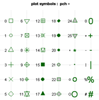

Figure 1. Plot symbols for data points using the pch function.

# Axis limit: `xlim` and `ylim`

We can adjust the limits of the x-axis and y-axis by using `xlim` and `ylim` functions. By adjusting these limits according to your data, you will be able to see all the data points inside of the graph area. The first number corresponds to the lower limit and the second to the upper limit.

# Title: `main`

Use this function to add a title to the graph. The name should be inside quotes (e. g. `main= “Height trend of leading species”`).

# Size control: `cex`

This function allows us to change the size of the data points, labels, title, and axes. Use `cex` to change the size of data points, `cex.lab` to change the size of titles in axes, `cex.axis` to change the size of numbers in the axes, and `cex.main` to change the size of the title of the graph.

# Simple graph

```r
# Check Current directory
getwd()
```

```
## [1] "C:/Syd/UBC/Teaching/GAA FRST 232"
```

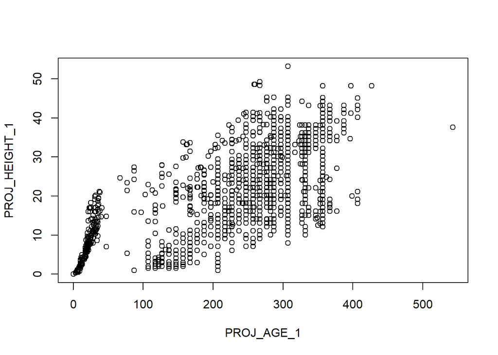

```r
# Importing VRI data
vri_data <- read.csv("VRI_data.csv", header = TRUE)

# Attach the data
attach(vri_data)

# Creating graph without controlling any element
plot(PROJ_AGE_1,PROJ_HEIGHT_1)
```

```r
# Insert important elements in the plot fucntion
plot(vri_data[,3],  vri_data[,4],
     xlab="Projected Age (years)",
     ylab="Projected Height (m)",
     type = "p",
     pch = 16,
     col = "black",
     ylim=c(0,70),
     xlim=c(0,600),
     cex=2,
     cex.lab=1.5,
     cex.axis=1.5,
     main="Height trend of leading species",
     cex.main=2)
```

[output not shown]

# Define parameters and call inside the plot function

```r
# Define All values

ylabel="Projected Height (m)"
xlabel="Projected Age (years)"
ylm=c(0,70)
xlm=c(0,600)
ldcex=2 # size of points
cxlb=1.5 # axis level - fontsize
cxaxis=1.5 # axis fontsize
maincx=2 # title font

titel="Height trend of leading species"


# Call the above paramters inside the plot fucntion
plot(PROJ_AGE_1,PROJ_HEIGHT_1,
     xlab=xlabel,
     ylab=ylabel,
     type = "p",
     pch = 16,
     col = "black",
     ylim=ylm,
     xlim=xlm,
     cex=ldcex,
     cex.lab=cxlb,
     cex.axis=cxaxis,
     main=titel,
     cex.main=maincx)
```

[output not shown]

# Plotting a graph

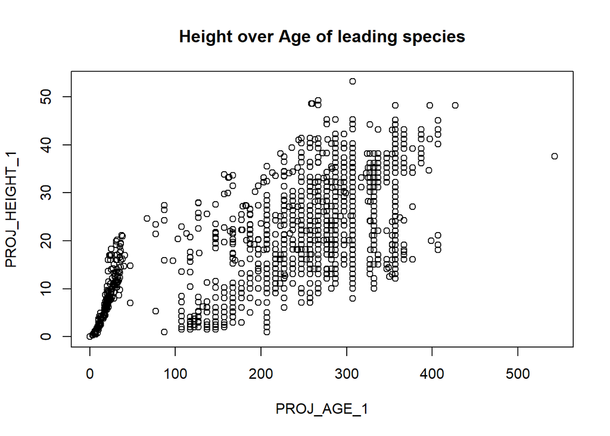

```r
# plain graph
plot(PROJ_AGE_1,PROJ_HEIGHT_1, main="Height over Age of leading species")
```

```r
# Add detail
age=PROJ_AGE_1
ht=PROJ_HEIGHT_1
ylabel="Projected Height (m)"
xlabel="Projected Age (years)"
ylm=c(0,70)
xlm=c(0,600)

cxlb=1.5 # axis level - fontsize
cxaxis=1.5 # axis fontsize
maincx=2 # title font


ldcex=2 # size of points
ld=4

# 1st  graph
plot(age, ht, xlab=xlabel, ylab=ylabel,   type = "p", pch = 16, col = "black", ylim=ylm, xlim=xlm, cex=ldcex, cex.lab=cxlb, cex.axis=cxaxis, main="Height trend of leading species", cex.main=maincx)
```

[output not shown]

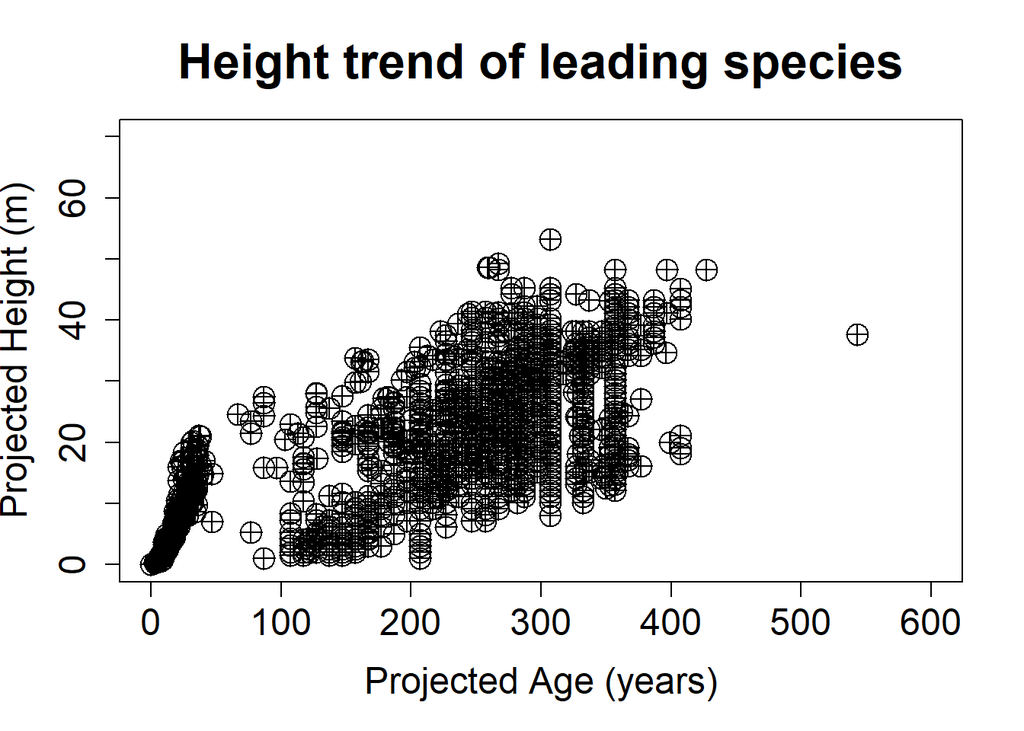

```r
# change symbol on the previous graph
plot(age, ht, xlab=xlabel, ylab=ylabel,   type = "p", pch = 10, col = "black", ylim=ylm, xlim=xlm, cex=ldcex, cex.lab=cxlb, cex.axis=cxaxis, main="Height trend of leading species", cex.main=maincx)
```

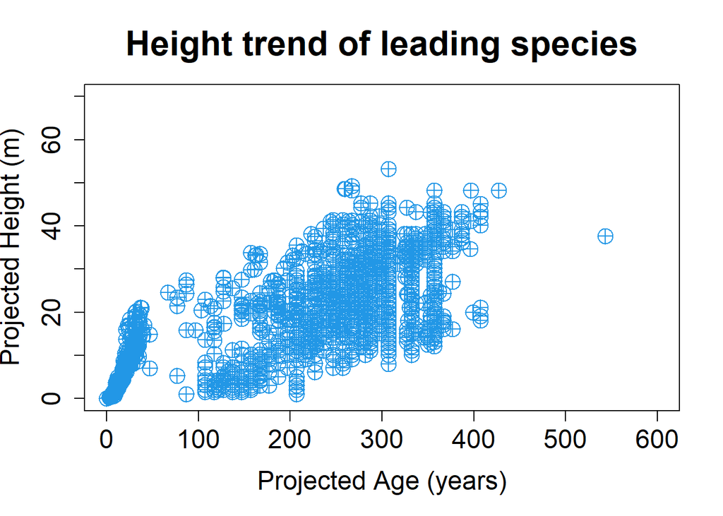

```r
# change colour on the previous graph

plot(age, ht, xlab=xlabel, ylab=ylabel,   type = "p", pch = 10, col = 84, ylim=ylm, xlim=xlm, cex=ldcex, cex.lab=cxlb, cex.axis=cxaxis, main="Height trend of leading species", cex.main=maincx)
```

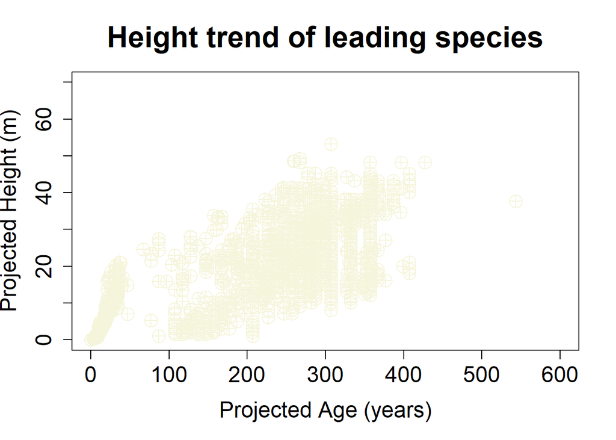

```r
plot(age, ht, xlab=xlabel, ylab=ylabel,   type = "p", pch = 10, col = "beige", ylim=ylm, xlim=xlm, cex=ldcex, cex.lab=cxlb, cex.axis=cxaxis, main="Height trend of leading species", cex.main=maincx)
```

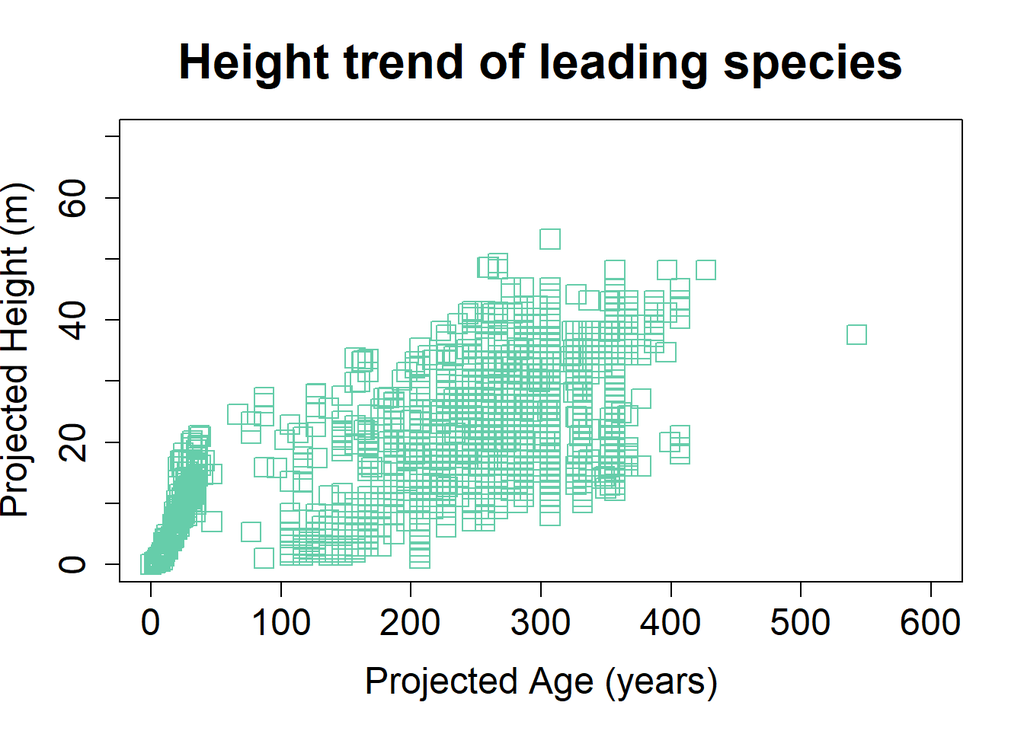

```r
plot(age, ht, xlab=xlabel, ylab=ylabel,   type = "p", pch = 22, col='#66CDAA',  ylim=ylm, xlim=xlm, cex=ldcex, cex.lab=cxlb, cex.axis=cxaxis, main="Height trend of leading species", cex.main=maincx)
```

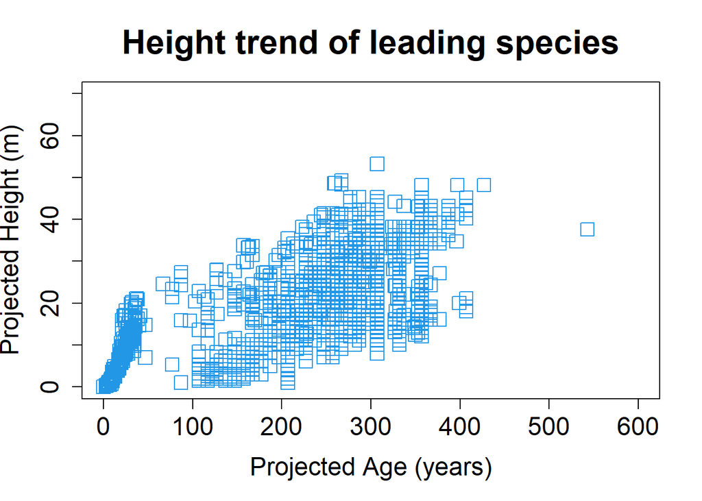

```r
plot(age, ht, xlab=xlabel, ylab=ylabel,   type = "p", pch = 22, col=68,  ylim=ylm, xlim=xlm, cex=ldcex, cex.lab=cxlb, cex.axis=cxaxis, main="Height trend of leading species", cex.main=maincx)
```

# Plotting a subset of data and plotting two datasets on the same graph

To plot a subset of data we should specify the data frame that we want to use as well as the variable from where we want to take the subset of data. To do this we should define x and y axes by using `plot(name_of_dataframe[name_of_column == “name_of_subset”])`, this will generate a graph with default attributes. To add specific features to our plot we can use any of the functions previously described inside of the parenthesis separated by commas `plot(name_of_dataframe[name_of_column1 == “name_of_subset”], name_of_dataframe[name_of_column2 == “name_of_subset”] type = “p”, pch = 1, col = “black”, main=“Height of leading species”)`.

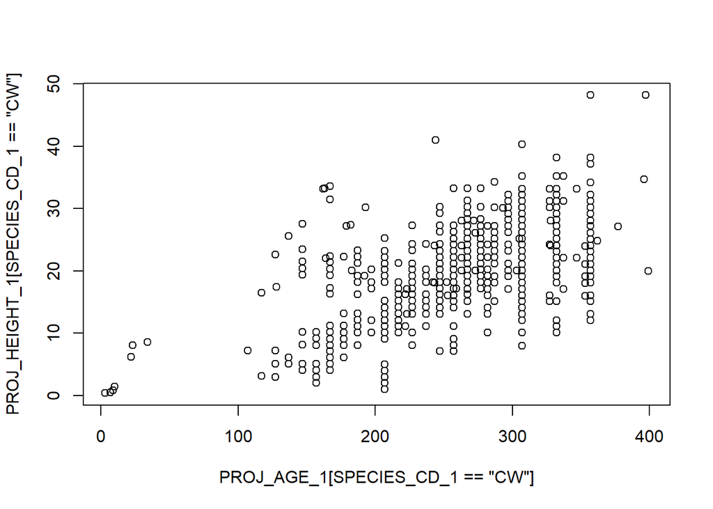

```r
# plot a subset: subset the data and plot together
plot(PROJ_AGE_1[SPECIES_CD_1 =='CW'],PROJ_HEIGHT_1[SPECIES_CD_1     =='CW'])
```

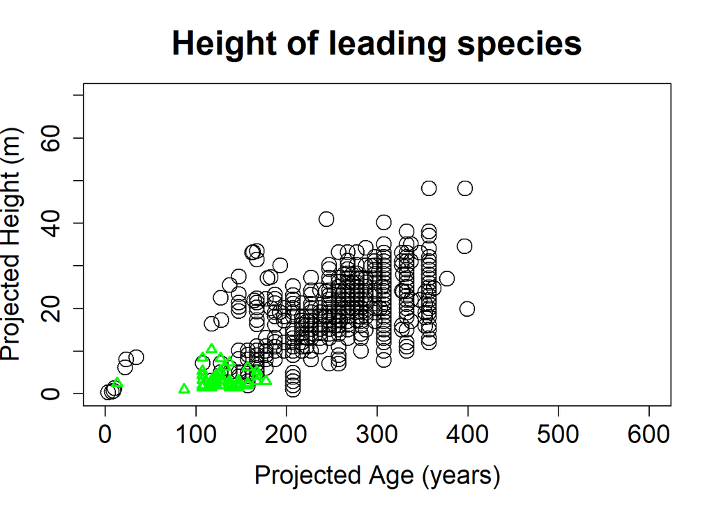

```r
# plot a subset and two dataset on the same graph

plot(PROJ_AGE_1[SPECIES_CD_1 =='CW'],PROJ_HEIGHT_1[SPECIES_CD_1     =='CW'], type = "p", pch = 1, col = "black", main="Height of leading species",  ylim=ylm, xlim=xlm, cex=ldcex, cex.lab=cxlb, cex.axis=cxaxis, cex.main=maincx,  xlab=xlabel, ylab=ylabel)
points(PROJ_AGE_1[SPECIES_CD_1 =='PLC'],    PROJ_HEIGHT_1[SPECIES_CD_1=='PLC'], type = "p", pch = 2, col = "green", lwd=2)
```

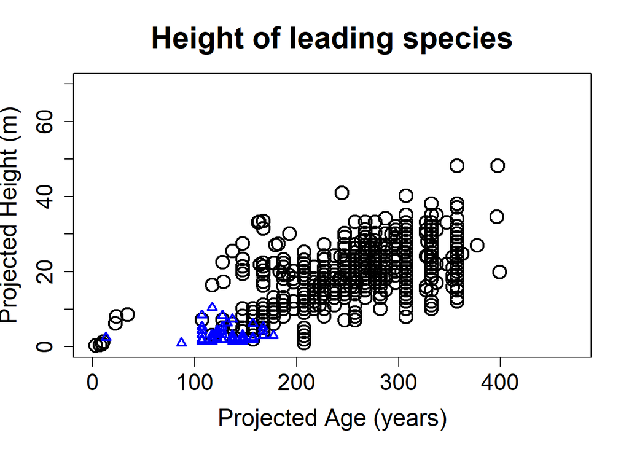

```r
# plot subset: alternatevely

# separating data by species
d1<- subset(vri_data, (SPECIES_CD_1 =='CW'))
d2<- subset(vri_data, (SPECIES_CD_1 =='PLC'))

# define elements

age=3 # age column number
ht=4 # heightt column number
ylabel="Projected Height (m)"
xlabel="Projected Age (years)"
ylm=c(0,70)
xlm=c(0,470)

cxlb=1.6 # axis level - fontsize
cxaxis=1.5 # axis fontsize
maincx=2 # title font

ldcex=2 # size ofpoints
ld=2

plot(d1[,age],d1[,ht], type = "p", pch = 1, col = "black", main="Height of leading species", ylim=ylm, xlim=xlm, cex=ldcex, cex.lab=cxlb, cex.axis=cxaxis, cex.main=maincx,  xlab=xlabel, ylab=ylabel, lwd=ld)
points(d2[,age],d2[,ht], type = "p", pch = 2, col = "blue", lwd=ld)
```

# Alternatively: Create the subset and then plot

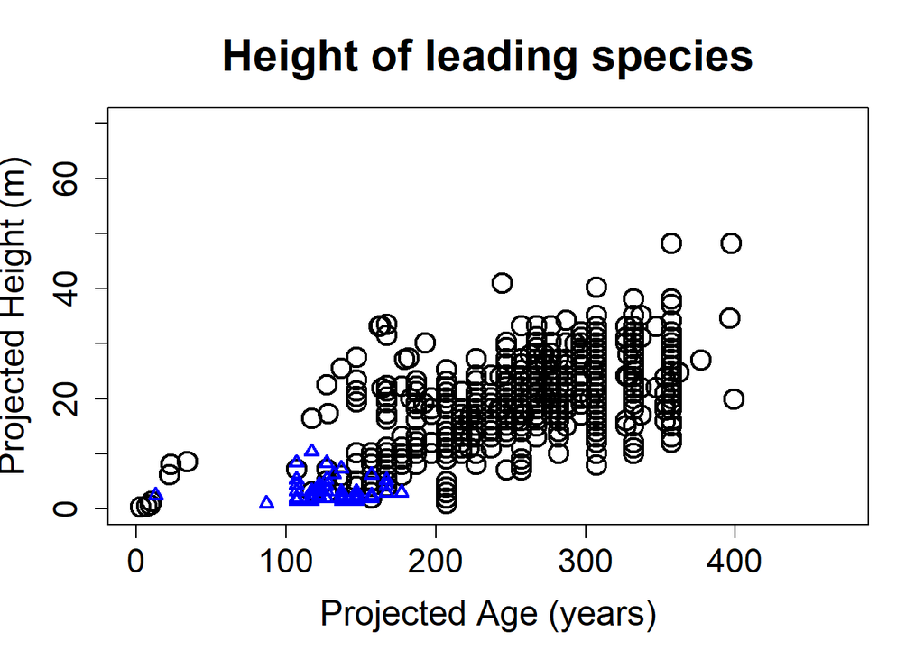

```r
# plot subset: alternatevely

# separating data by species
d1<- subset(vri_data, (SPECIES_CD_1 =='CW'))
d2<- subset(vri_data, (SPECIES_CD_1 =='PLC'))

# define elements
age=3 # age column number
ht=4 # heightt column number
ylabel="Projected Height (m)"
xlabel="Projected Age (years)"
ylm=c(0,70)
xlm=c(0,470)

cxlb=1.6 # axis level - fontsize
cxaxis=1.5 # axis fontsize
maincx=2 # title font

ldcex=2 # size ofpoints
ld=2

plot(d1[,3],d1[,4], type = "p", pch = 1, col = "black", main="Height of leading species", ylim=ylm, xlim=xlm, cex=ldcex, cex.lab=cxlb, cex.axis=cxaxis, cex.main=maincx,  xlab=xlabel, ylab=ylabel, lwd=ld)
points(d2[,3],d2[,4], type = "p", pch = 2, col = "blue", lwd=ld)
```

# Controlling margins

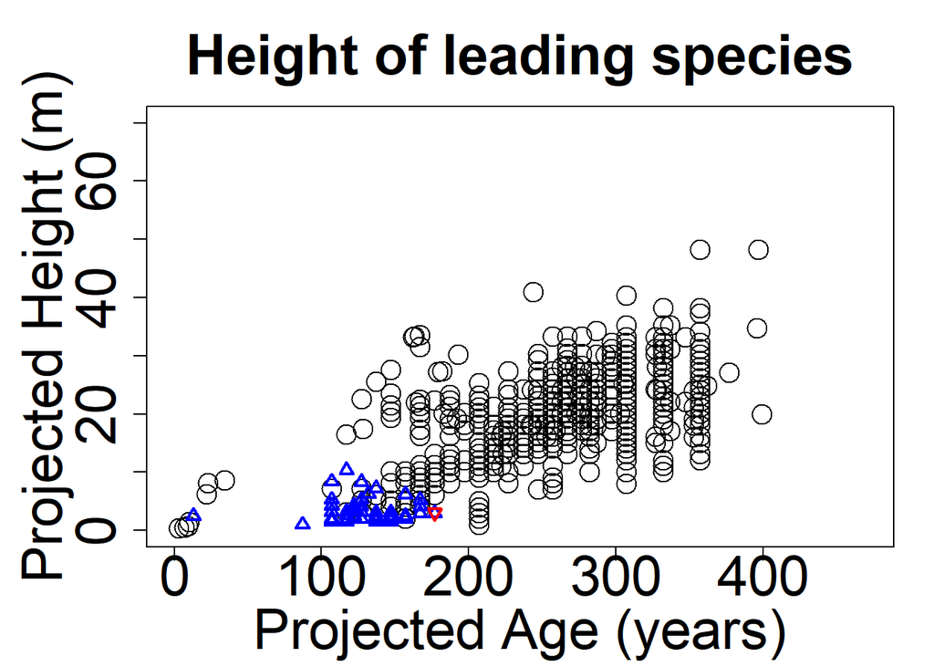

```r
# Defining parameters
ylabel="Projected Height (m)"
xlabel="Projected Age (years)"
ylm=c(0,70)
xlm=c(0,470)

cxlb=2.5 # axis level - fontsize
cxaxis=2.5 # axis fontsize
maincx=2.5 # title font

age=3 # age column number
ht=4 # heightt column number
ldcex=2 # size ofpoints
ld=2

# Finding the height value at the maximum age
maxd1<- max(d2[,age]) # maximum age
m1<-subset(d2, PROJ_AGE_1==maxd1) # height value at the maximum age


# Setting margin
par(mfrow=c(1,1),mai=c(0.9,1.1,0.8,0.3), cex=1.0 ) # mai is the margin

# Creating a single graph
plot(d1[,age],d1[,ht], type = "p", pch = 1, col = "black", main="Height of leading species",    ylim=ylm, xlim=xlm, cex=ldcex, cex.lab=cxlb, cex.axis=cxaxis, cex.main=maincx,  xlab=xlabel, ylab=ylabel)
points(d2[,age],d2[,ht], type = "p", pch = 2, col = "blue", lwd=ld)
points(m1[,age],m1[,ht], type = "p", pch = 6, col = "red", lwd=ld)
```

```r
# we can show the mean value as well
mean(d2[,age])
```

```
## [1] 121.8132
```

```r
# exercise: show the mean value in agraph
```